# Organise Data

James Foster

2026-09-30

# References

> Natalie Cooper & Pen-Yuan Hsing, 2017 [A Guide to Reproducible Code in Ecology and Evolution](https://britishecologicalsociety.org/wp-content/uploads/2017/12/guide-to-reprhducible-chde.pdf) British Ecological Society

# TODO

- Load data +
- Reorganise +
- Add solar azimuth +
- Export +
- Adjust times for dome videos +
- Incorporate calibrated dances +
- Calculate dance - sun angle before feeder angle +
- Map out feeder and hive positions

# Load functions and packages

Load the packages and other functions that will be used during reorganisation.

```r
source('HS_functions.R')
```

# Load data

## Load the raw data

Load the raw data exported from Excel to `csv`.

```r
path_file = file.path("0Data",
                      c(
                        "V_uncalib.csv",#vertical dances (not yet calibrated0)
                        "H_calib.csv",#horizontal and dome calibrated dances
                        "T_calib.csv"#tilted-above-horizontal calibrated dances
                        )
)
if(any(!file.exists(path_file)))
{print(paste(path_file, '\nnot found'))}
hd = lapply(X = path_file,
            FUN = read.table,
                header = T,
                sep  = ',')
```

## Combine calibrated and uncalibrated data

Check that all column names match across files loaded.

```r
nm_vert = names(hd[[1]])
nm_horiz = names(hd[[2]])
nm_tilt = names(hd[[3]])
if(any(!(nm_horiz %in% nm_vert) |
       !(nm_vert %in% nm_horiz) |
       !(nm_tilt %in% nm_vert) |
       !(nm_vert %in% nm_tilt)
       )
   )
{
  message("horizontal columns not in vertical")
print(nm_horiz[!(nm_horiz %in% nm_vert)])
  message("vertical columns not in horizontal")
print(nm_vert[!(nm_vert %in% nm_horiz)])
message("vertical columns not in tilted")
print(nm_vert[!(nm_vert %in% nm_tilt)])
message("tilted columns not in vertical")
print(nm_tilt[!(nm_tilt %in% nm_vert)])
message("removing columns not in tilted")
hd[[1]] = within(hd[[1]], {
  rm(list = paste(nm_vert[!(nm_vert %in% nm_tilt)]))
})
hd[[2]] = within(hd[[2]], {
  rm(list = paste(nm_vert[!(nm_vert %in% nm_tilt)]))
})
message("removing columns of tilted not in vertical")
hd[[3]] = within(hd[[3]], {
  rm(list = paste(nm_tilt[!(nm_tilt %in% nm_vert)]))
})
print("mismatches remaining: ")
print(names(hd[[1]])[!(names(hd[[1]]) %in% nm_tilt)])
print(names(hd[[2]])[!(names(hd[[2]]) %in% nm_tilt)])
print(names(hd[[3]])[!(names(hd[[3]]) %in% nm_vert)])
print(names(hd[[3]])[!(names(hd[[3]]) %in% nm_horiz)])
}else
{print("columns match in all CSVs")}
```

```
## [1] "columns match in all CSVs"
```

Bind the tables together one set of rows on top of the other

```r
hd = do.call(what = rbind,
             args = hd)
```

## Inspect data

Exported CSVs sometimes end up with empty rows at the end. Check that the last row contains data.

```r
print(hd[dim(hd)[1],])
```

```
##      recording_type    source_batch                       dance_key  dance_id
## 4705         tilted tilted_20250128 tilted_20250128__95r__95r_00067 95r_00067
##      bee_id     date time_dance waggle_run condition orientation_method
## 4705    95r 20250128   18:12:00         16    10_deg     direct_compass
##                              csv_file
## 4705 95r_00067_waggle_annotations.csv
##                                               video_name direction_u
## 4705 E:\\2026Trackathon\\James\\mp4\\20250128\\00067.mp4  -0.7348034
##      direction_v video_angle_deg true_north_video_deg waggle_true_bearing_deg
## 4705   0.6782801        227.2906             169.4915                57.79912
##      mean_magnetic_north_deg true_north_calibration_deg compass_circular_sd_deg
## 4705                148.2215                   169.4915                1.068727
##      calibration_n_annotations calibration_quality_flag
## 4705                        10                       ok
##                 reference_compass_file         assigned_calibration_file
## 4705 20250128/28_calibration_00062.csv 20250128/28_calibration_00062.csv
##            calibration_id                  calibration_file
## 4705 28_calibration_00062 20250128/28_calibration_00062.csv
##      reference_landmark_file landmark_dance_file landmark_calibration_deg
## 4705                                                                   NA
##      landmark_calibration_circular_sd_deg north_relative_to_landmark_deg
## 4705                                   NA                             NA
##      landmark_dance_video_deg landmark_dance_circular_sd_deg start_x start_y
## 4705                       NA                             NA    1152     773
##         start_xy start_frame notes calibration_R declination_deg
## 4705 (1152, 773)         885  <NA>            NA          -21.27
```

Last row contains at some data, no extra empty rows.

**Click to expand raw data**

```r
print(hd)
```

```
##      recording_type               source_batch
## 1          vertical          vertical_20250119
## 2          vertical          vertical_20250119
## 3          vertical          vertical_20250119
## 4          vertical          vertical_20250119
## 5          vertical          vertical_20250119
## 6          vertical          vertical_20250119
## 7          vertical          vertical_20250119
## 8          vertical          vertical_20250119
## 9          vertical          vertical_20250119
## 10         vertical          vertical_20250119
## 11         vertical          vertical_20250119
## 12         vertical          vertical_20250119
## 13         vertical          vertical_20250119
## 14         vertical          vertical_20250119
```

[output cut: 37486 more lines]

# Reorganise

```r
names(hd)
```

```
##  [1] "recording_type"
##  [2] "source_batch"
##  [3] "dance_key"
##  [4] "dance_id"
##  [5] "bee_id"
##  [6] "date"
##  [7] "time_dance"
##  [8] "waggle_run"
##  [9] "condition"
## [10] "orientation_method"
## [11] "csv_file"
## [12] "video_name"
## [13] "direction_u"
## [14] "direction_v"
## [15] "video_angle_deg"
```

[output cut: 25 more lines]

## Rename variables

Rename some variables with shorter or easier to recognise names. Video names currently include the full path for the user that annotated them these can be simplified to just file name and folder (date recorded). There are two kinds of grouping factor, firstly the identity of the individual bee, simplified here to `ID`, and within each individual bee their individual dances, specified here as `ID_d`. The date is now in `YYYYMMDD` format, this will be reformatted later.

```r
#from the list above, identify unused or renamed columns to remove
rm_lst = c(
  "recording_type", #not used currently
  "source_batch", #not used currently
  "dance_key", #not used currently
  "dance_id", #renamed
  "bee_id", # renamed
  "date", #renamed
  "time_dance", #renamed
  # [8,] "waggle_run"
  # [9,] "condition"
  "orientation_method", #not currently used
  # [11,] "csv_file"
  "video_name", #should be identifiable from video_file
  # [13,] "direction_u"
  # [14,] "direction_v"
  # [15,] "video_angle_deg"
  # [16,] "true_north_video_deg"
  # [17,] "waggle_true_bearing_deg"
  # [18,] "mean_magnetic_north_deg"
  # [19,] "true_north_calibration_deg"
  "compass_circular_sd_deg", #not currently used
  "calibration_n_annotations", #not currently used
  # [22,] "calibration_quality_flag"
  "reference_compass_file", #not currently used
  "assigned_calibration_file", #not currently used
  "calibration_id", #not currently used
  "calibration_file", #not currently used
  "reference_landmark_file", #not currently used
  "landmark_dance_file", #not currently used
  "landmark_calibration_deg", #not currently used
  "landmark_calibration_circular_sd_deg", #not currently used
  "north_relative_to_landmark_deg", #not currently used
  "landmark_dance_video_deg", #not currently used
  "landmark_dance_circular_sd_deg", #not currently used
  # [34,] "start_x"
  # [35,] "start_y"
  "start_xy", #same as start_x, start_y
  "start_frame", #not currently used
  "notes"
  # [39,] "calibration_R"
  # [40,] "declination_deg"
)

#rename and remove unused or renamed
hd = within(hd, {
  ID = paste0(bee_id) # individual identifier
  ID_d = paste0(dance_id, "_", time_dance, "_", date) # dance identifier
  time = time_dance
  day = date # this will need to be converted to POSIX format

  video_file = file.path(
    basename(dirname(video_name)), #just the folder
    basename(video_name)
  ) # and file name
  #clean up information that has been doubled or will not be used
  rm(list = rm_lst)
})
#confirm resulting columns
names(hd)
```

```
##  [1] "waggle_run"                 "condition"
##  [3] "csv_file"                   "direction_u"
##  [5] "direction_v"                "video_angle_deg"
##  [7] "true_north_video_deg"       "waggle_true_bearing_deg"
##  [9] "mean_magnetic_north_deg"    "true_north_calibration_deg"
## [11] "calibration_quality_flag"   "start_x"
## [13] "start_y"                    "calibration_R"
## [15] "declination_deg"            "video_file"
## [17] "day"                        "time"
## [19] "ID_d"                       "ID"
```

## Identify factor levels

Some of the character variables could be treated as factors. Inspect the different labels to each to check these are informative.

**Click to expand full list**

```r
nm_fact = c(
  # [1,] "waggle_run"
  "condition",
  # "csv_file", #easier to handle file paths as characters
  # [4,] "direction_u"
  # [5,] "direction_v"
  # [6,] "video_angle_deg"
  # [7,] "true_north_video_deg"
  # [8,] "waggle_true_bearing_deg"
  # [9,] "mean_magnetic_north_deg"
  # [10,] "true_north_calibration_deg"
  "calibration_quality_flag",
  # [12,] "start_x"
  # [13,] "start_y"
  # [14,] "calibration_R"
  # [15,] "declination_deg"
  # "video_file", #easier to handle file paths as characters
  # [17,] "day"
  # [18,] "time"
  "ID_d",
  "ID"
)

sapply(X = hd[, nm_fact],
       unique
     )
```

```
## $condition
## [1] "vertical"         "horizontal"       "antisolar"        "solar"
## [5] "zenith"           "10_deg"           "5_deg"            "above_horizontal"
##
## $calibration_quality_flag
## [1] NA                    "few_annotations"     "ok"
## [4] "only_one_annotation" ""
##
## $ID_d
##   [1] "16b_00033_17:20:00_20250119"
##   [2] "22b_00028_16:57:00_20250119"
##   [3] "22b_00030_17:03:00_20250119"
##   [4] "22b_00035_17:24:00_20250119"
##   [5] "22b_00039_17:30:00_20250119"
##   [6] "22b_00041_17:37:00_20250119"
```

[output cut: 408 more lines]

## Reformat variables

Reformat variables to factor and numeric. Everything else remains character format by default.

```r
nm_num = c(
  "waggle_run",
  # "condition",
  # "csv_file",
  "direction_u",
  "direction_v",
  "video_angle_deg",
  "true_north_video_deg",
  "waggle_true_bearing_deg",
  "mean_magnetic_north_deg",
  "true_north_calibration_deg",
  # "calibration_quality_flag",
  "start_x",
  "start_y",
##  "calibration_R", ##Removed temporarily
  "declination_deg",
  # "video_file",
  "day"
  # "time" # this is character but neither factor nor numeric
  # "ID_d",
  # "ID"
)
#format factors
for(nm in nm_fact)
{
hd[, nm] = as.factor(hd[, nm])
}

#format numeric
for(nm in nm_num)
{
hd[, nm] = as.numeric(hd[, nm])
}

summary(hd)
```

```
##    waggle_run               condition      csv_file          direction_u
##  Min.   : 1.00   vertical        :1757   Length:4705        Min.   :-1.0000
##  1st Qu.: 3.00   horizontal      :1375   Class :character   1st Qu.:-0.8682
##  Median : 7.00   antisolar       : 677   Mode  :character   Median :-0.3610
##  Mean   :10.66   solar           : 435                      Mean   :-0.2385
##  3rd Qu.:14.00   10_deg          : 360                      3rd Qu.: 0.2487
##  Max.   :94.00   above_horizontal:  44                      Max.   : 1.0000
##                  (Other)         :  57
##   direction_v      video_angle_deg true_north_video_deg waggle_true_bearing_deg
##  Min.   :-1.0000   Min.   :  0.0   Min.   : 32.82       Min.   :  0.1633
##  1st Qu.:-0.5812   1st Qu.:151.4   1st Qu.:171.36       1st Qu.: 51.1004
##  Median : 0.1288   Median :216.3   Median :220.84       Median : 84.2605
##  Mean   : 0.1057   Mean   :204.0   Mean   :209.30       Mean   :133.7225
##  3rd Qu.: 0.8321   3rd Qu.:273.7   3rd Qu.:248.97       3rd Qu.:233.2757
##  Max.   : 1.0000   Max.   :359.3   Max.   :356.63       Max.   :359.8506
##                                    NA's   :1757         NA's   :1757
##  mean_magnetic_north_deg true_north_calibration_deg
##  Min.   : 25.29          Min.   : 46.56
##  1st Qu.:148.22          1st Qu.:102.78
##  Median :191.77          Median :169.49
##  Mean   :184.75          Mean   :190.15
##  3rd Qu.:227.70          3rd Qu.:285.62
##  Max.   :325.33          Max.   :346.60
##  NA's   :1757            NA's   :3103
##         calibration_quality_flag    start_x          start_y
##                     : 430        Min.   : 133.0   Min.   :  13.0
##  few_annotations    : 128        1st Qu.: 699.0   1st Qu.: 739.0
##  ok                 :2386        Median : 896.0   Median : 818.0
##  only_one_annotation:   4        Mean   : 933.1   Mean   : 792.4
##  NA's               :1757        3rd Qu.:1134.0   3rd Qu.: 878.0
##                                  Max.   :2417.0   Max.   :1067.0
##
##  calibration_R    declination_deg   video_file             day
##  Min.   :0.9979   Min.   :-21.27   Length:4705        Min.   :20250119
##  1st Qu.:0.9995   1st Qu.:-21.27   Class :character   1st Qu.:20250121
##  Median :0.9997   Median :-21.27   Mode  :character   Median :20250126
##  Mean   :0.9995   Mean   :-21.27                      Mean   :20250125
##  3rd Qu.:0.9998   3rd Qu.:-21.27                      3rd Qu.:20250128
##  Max.   :1.0000   Max.   :-21.27                      Max.   :20250128
##  NA's   :3359     NA's   :58
##      time                                    ID_d            ID
##  Length:4705        73b_00027_16:51:00_20250119:  94   22b    : 866
##  Class :character   66b_00027_10:49:00_20250128:  57   20y    : 614
##  Mode  :character   84r_00048_15:36:00_20250123:  57   73b    : 474
##                     11r_00048_15:36:00_20250123:  56   90r    : 424
##                     20y_00006_08:23:00_20250128:  56   95r    : 340
##                     22b_00030_17:03:00_20250119:  51   66b    : 306
##                     (Other)                    :4334   (Other):1681
```

There appears to have been an autofill error in condition labelling. Rename all unexpected stimuli to `deg_10`, 10° above horizontal. *20260818* Has this been fixed? Could skip. *20260825* Currently no `deg_10` data, will keep in case this is added later. *20260916* There is now a variety of tilted data at two different angles, all now assigned as “tilted”.

```r
hd = within(hd,
            {
              condition = sapply(as.character(condition),
                                switch,
                                vertical = "vertical",
                                horizontal = "horizontal",
                                antisolar = "antisolar",
                                solar = "solar",
                                zenith = "zenith",
                                deg_10 = "tilted",
                                "tilted")#otherwise always deg_10
            }
            )
#How many dances were neither vertical or horizontal?
with(subset(hd, condition %in% "tilted"),
     {length(unique(ID_d))} )
```

```
## [1] 31
```

```r
with(hd, unique(condition))
```

```
## [1] "vertical"   "horizontal" "antisolar"  "solar"      "zenith"
## [6] "tilted"
```

## Check variable structure

Each dance should have only one time code, one condition and one bee.

```r
#individuals per dance
if(
all(
summary(
  sapply(X = unique(hd$ID_d),
               FUN = function(id){
                 with(subset(hd, ID_d %in% id),
                          {length(unique(ID))} )
               }
  )
) == 1)
){print("Each dance has only one dancer")}else
{message("Some dances do not have one dancer\n")}
```

```
## [1] "Each dance has only one dancer"
```

```r
#times per dance
if(
all(
summary(
  sapply(X = unique(hd$ID_d),
               FUN = function(id){
                 with(subset(hd, ID_d %in% id),
                          {length(unique(time))} )
               }
  )
) == 1)
){print("Each dance has only one time stamp")}else
{message("Some dances do not have one time stamp\n")}
```

```
## [1] "Each dance has only one time stamp"
```

```r
#days per dance
if(
  all(
summary(
  sapply(X = unique(hd$ID_d),
               FUN = function(id){
                 with(subset(hd, ID_d %in% id),
                          {length(unique(day))} )
               }
  )
) == 1)
){print("Each dance has only one day")}else
{message("Some dances do not have one day\n")}
```

```
## [1] "Each dance has only one day"
```

```r
#stimuli per dance
if(
  all(
summary(
  sapply(X = unique(hd$ID_d),
               FUN = function(id){
                 with(subset(hd, ID_d %in% id),
                          {length(unique(condition))} )
               }
  )
) == 1)
){print("Each dance has only one condition")}else
{message("Some dances do not have one condition\n")}
```

```
## [1] "Each dance has only one condition"
```

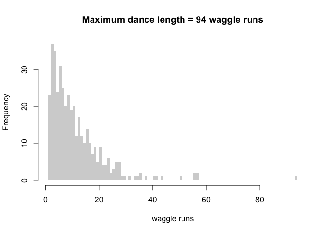

```r
#how many waggle runs per dance?
runs_per_dance =  sapply(X = unique(hd$ID_d),
               FUN = function(id){
                 with(subset(hd, ID_d %in% id),
                          {max(waggle_run)} )
               }
  )

hist(runs_per_dance,
     breaks = max(runs_per_dance),
     main = paste('Maximum dance length =',
                  max(runs_per_dance), 'waggle runs'),
     xlab = 'waggle runs',
     border = NA)
```

# Add sun location

We can now use the time and date for each dance, combined with the location of the hive and feeder, to work out the relative positions of the hive, sun and feeder. This tells us what direction each dance should indicate for the feeder, as well as any potential effects of sun elevation on accuracy or skylight quality.

## Check times and dates

```r
#firstly, remove any dances that include neither video nor data
empty_dances = with(subset(hd,
                           subset = is.na(video_angle_deg) &
                                     video_file %in% "/"), # result of file.path('','')
                    unique(ID_d)
                    )
if(length(empty_dances)>0)
{
  print("removing empty dances:")
  print(as.character(t(t(empty_dances))))
hd = subset(hd,
            subset = !(ID_d %in% empty_dances)
            )
}

missing_time = c('na', '')

#how many dances have day missing
if(any(is.na(hd$day)))
{
  message(paste(
with(subset(hd, is.na(day)),
     length(unique(ID_d))
     ),
"dances are missing the date")
)
#very few, which ones?
print(
with(subset(hd, is.na(day)),
     t(t(unique(video_file)))
     )
)
#some of these can be determined from the video name
hd = within(hd,
            {
              #guess the date
              day_guess = sub(x = dirname(video_file),#just the folder
                                                pattern = "_new$", #remove "_new"
                                               replacement = "")
            }
            )

#no guesses are NA
message(paste(
with(subset(hd, is.na(day_guess)),
     length(unique(ID_d))
     ),
"dance dates could not be guessed from file name")
)

#one guess is not a date
message(paste("guesses not found in list of dates:\n",
with(subset(hd, !(as.numeric(day_guess) %in% as.numeric(day[!is.na(day)]))),
     unique(day_guess)
     )
)
)


#replace NAs with guesses
hd = within(hd,
            {
            day = ifelse(test = is.na(day) & #if day is NA
                           as.numeric(day_guess) %in% #guess is one of the
                           as.numeric(day[!is.na(day)]),#known dates
                          yes = day_guess,
                          no = day) # don't replace unless sure
            rm('day_guess')#no longer needed
            }
            )

message(paste(
#check after updating
with(subset(hd, is.na(day)),
     length(unique(ID_d))
     ),
"unidentified dates after guessing"
)
)

}

#how many have time missing
if(any(is.na(hd$time %in% missing_time)))
{
    message(paste(
with(subset(hd, time %in% missing_time),
     length(unique(ID_d))
     ),
"dances are missing the date")
)
}

#how many cannot be converted to calendar dates
hd = within(hd,
       {
       date_fail = is.na(
              as.POSIXct(mapply(FUN = paste,
                                 day,
                                 time),
                                      format = "%Y%m%d %H:%M:%OS")#time in YYYY-MM-DD HH:MM:SS
)
              }
              )

#Of these how many are missing waggle runs?
# print(with(subset(hd, subset = date_fail), mean(is.na(video_angle_deg)) ), digits = 2)

#if
if(any(hd$date_fail))
{
message(paste(
with(subset(hd, date_fail),
     length(unique(ID_d))
     ),
"dances _could not_ be assigned a calendar date"
))
#which videos are missing time or date
message(paste("calendar dates not assigned for:\n",
  with(subset(x = hd,
            subset =  is.na(day) | time %in% missing_time),
     {t(t(as.character(unique(video_file))))})
)
)

#which videos cannot be converted but are not missing time
message(paste("time found but not calendar dates for:\n",
  with(subset(x = hd,
            subset =  date_fail & !(time %in% missing_time) ),
     {
       t(t(as.character(unique(video_file))))
       }
     )
 )
)
}else
{print("all dances assigned a calendar date")}
```

```
## [1] "all dances assigned a calendar date"
```

All dances can be assigned a calendar date without the need for guessing.

## Set up times

First we need to combine dates in `YYYYMMDD` with times in `HH:MM:SS` to produce a POSIX/C99 “calendar time” for each. This is then converted to UTC for sun location estimation.

```r
hd = within(hd,
            {
              time_code = mapply(FUN = paste,
                                 day,
                                 time)#time in YYYY-MM-DD HH:MM:SS
              sast_time =  as.POSIXct(time_code,
                                      tz = "Africa/Johannesburg",
                                      format = "%Y%m%d %H:%M:%OS")#South African Standard time
              utc_time =  as.POSIXct(sast_time, tz = "UTC")#UTC time
              rm("time_code")#now duplicated
            }
)
with(hd, summary(utc_time))
```

```
##                  Min.               1st Qu.                Median
## "2025-01-19 14:51:00" "2025-01-21 14:35:00" "2025-01-26 16:13:00"
##                  Mean               3rd Qu.                  Max.
## "2025-01-25 06:15:08" "2025-01-28 06:58:00" "2025-01-28 16:43:00"
```

In all cases time or date were available and could be converted, so it will be possible to calculate the sun’s azimuth for all of these.

### Adjust for laptop clock (check this)

Videos recorded on the laptop have time stamps in CET not SAST. This means that they are one hour behind, since South African Summer time is `UCT + 2`, while Central European Winter is `UTC + 1`. Before calculating sun position, we should check that all times have been adjusted by adding one hour (60 minutes x 60 seconds). Below we estimate the correct time by extracting the time stamp from the video name and converting to SAST. This is then compared with the time generated from our notes, with a margin of error `expected_diff`. This is currently set to 5 minutes, which during the fastest rate of sun azimuth change of ≈2°/minute would result in a maximum sun azimuth error of 10°.

```r
#upper limit of 5 minutes (x 60sec) between dance time and video saving
expected_diff = 5*60

extract_timestamp = function(string) {
  # Match a timestamp in the form: YYYY-MM-DD HH-MM-SS
  # Example: "2025-01-20 14-25-03"
  m = regexpr(
    pattern = "\\d{4}-\\d{2}-\\d{2} \\d{2}-\\d{2}-\\d{2}",
    text = as.character(string)
  )

  # Prepare output vector with NA values by default
  # This ensures every input gets a corresponding output element
  out = rep(NA_character_, length(string))

  # Identify which entries actually contain a matching timestamp
  ok = m > 0

  # Extract the matched substring only for entries with a valid match
  # substr() takes: start position, end position
  out[ok] = substr(
    string[ok],
    m[ok],
    m[ok] + attr(m, "match.length")[ok] - 1
  )

  # Return extracted timestamps, with NA for entries that did not match
  out
}

calc_expected_time =  function(cond,
                               ts,
                               sast)
  {
    switch(EXPR = cond, #by condition label
      vertical = sast, #these video names don't have a timestamp
      horizontal = sast,#these video names don't have a timestamp
      tilted = sast,#these video names don't have a timestamp
      antisolar = ts + 60 * 60, #these time stamps are in CET
      solar = ts + 60 * 60, #these time stamps are in CET
      zenith = ts + 60 * 60, #these time stamps are in CET
      sast # by default assume correct
    )
  }

#try to generate the expected time
hd = within(hd,
            {
             # Try to read the original video timestamp from video_file first, then csv_file, then ID_d
            video_timestamp_txt = extract_timestamp(video_file)
            video_timestamp_txt = ifelse(test = is.na(video_timestamp_txt),
                                         yes = extract_timestamp(csv_file),
                                         no = video_timestamp_txt
                                         )
            video_timestamp_txt = ifelse(test = is.na(video_timestamp_txt),
                                         yes = extract_timestamp(ID_d), #constructed in the same way as sast_time?
                                         no = video_timestamp_txt
                                         )
            video_timestamp = as.POSIXct(
                                        video_timestamp_txt,
                                        format = "%Y-%m-%d %H-%M-%S",
                                        tz = "Africa/Johannesburg"
                                        )
            #for all videos recorded on the laptop generate an estimated time, others use SAST time generated above
            expected_time = mapply(FUN = calc_expected_time,
                                   cond = condition, # experimental condition (determined laptop or camcorder)
                                   ts = video_timestamp, # time from video
                                   sast = sast_time, # time from notes
                                   SIMPLIFY = TRUE)
            #calculate difference between time calculated from notes and time from video
            oe_time_diff = as.numeric(sast_time - expected_time) # difference in seconds
            time_error = abs(oe_time_diff) > expected_diff # is difference larger than expected (logical)
            }

            )

#notify the user
if (any(hd$time_error)) {
  with(subset(hd, time_error),
       {
         message(paste('Time error found for:\n',
        unique(video_timestamp)
         ))
       }
  )
}else
  {
  print("All timestamps are close to observed time.")
  print("Differences in minutes (estimated time - notes)")
  with(subset(hd, condition %in% c("solar", "antisolar", "zenith")),
       {
         print(summary(oe_time_diff/60),
               digits = 2)}
       )
  #clean up new variables
  hd = within(hd,
              {
                rm(list = c('video_timestamp_txt',
                            'video_timestamp',
                            # 'expected_time' #keep in case this is needed later
                            'oe_time_diff',
                            'time_error'
                            )
                )
              }
              )
}
```

```
## [1] "All timestamps are close to observed time."
## [1] "Differences in minutes (estimated time - notes)"
##    Min. 1st Qu.  Median    Mean 3rd Qu.    Max.
##  -4.750  -0.767  -0.167  -0.087   0.567   2.800
```

## Inspect experiment times

Convert these time codes to just time-of-day and plot a histogram to check that they fit with recorded times of experiments.

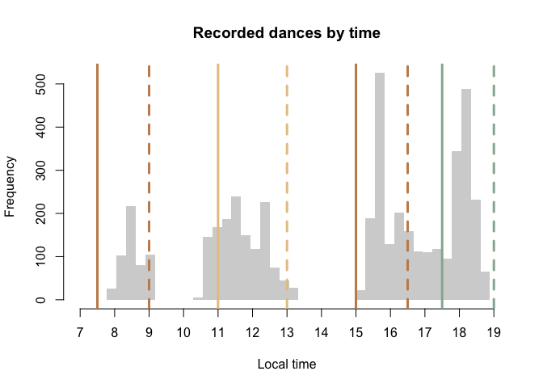

```r
#assign experiment times
morning_start = 7.50*60*60
morning_end = 9.00*60*60
midday_start = 11.00*60*60
midday_end = 13.00*60*60
afternoon_start = 15.00*60*60
afternoon_end = 16.50*60*60
evening_start = 17.50*60*60
evening_end = 19.00*60*60

exper_times = c(
  morning_start,
  morning_end,
  midday_start,
  midday_end,
  afternoon_start,
  afternoon_end,
  evening_start,
  evening_end
)


time_cols = c(
  morning_start   = "#C68B59",
  morning_end     = "#C68B59",
  midday_start    = "#E6C594",
  midday_end      = "#E6C594",
  afternoon_start = "#C68B59",
  afternoon_end   = "#C68B59",
  evening_start   = "#94B49F",
  evening_end     = "#94B49F"
)


with(hd,
     hist(x = GetToD(time),
          breaks = 12*60/15 +1,
          xlim = c(7, 19)*60*60,
          freq = TRUE,
          main = "Recorded dances by time",
          xlab = "Local time",
          axes = FALSE,
          border = NA),
     )
axis(side = 1,
     at = 7:19*60*60,
     labels = 7:19)
axis(side = 2)
#add lines indicating the approximate expected start and end of each experiment
abline(v = exper_times,
       col = time_cols,
       lty = c(1,2),
       lwd = 3
       )
```

Most dances appear during the target windows, with the exception of the late afternoon (16:30–17:30). It is possible that during periods of high activity we continued to record dances between the afternoon and evening experiments, at the transition from medium to low elevations.

## Estimate sun location

In order to determine the sun’s location (azimuth and elevation) we need to combine the time with the geographic location. `GetSaz` is a vectorised wrapper for `oce::sunAngle`, which corrects for refraction, but not the altitude from which the sun is viewed.

The current estimate of hive location is from a combination of Google Maps bookmarks and photograph metadata, cross-references with Google Earth satellite images.

```r
# Hive position
# 25° 34' 18" S, 31° 10' 48" E
#-25.57167,      31.18000

hive = r"(25° 34' 18" S, 31° 10' 48" E)" # N.B. this string contains literal " so needs wrapping in r"()"

# Define coordinates (lon, lat)
hive = Dms2decimal(hive)

#add sun azimuth
hd = within(hd,
            {
            sun_az = mapply(
                   FUN = GetSaz,
                   tm = utc_time,
                   lon = hive['longitude'],
                   lat = hive['latitude']
                   )
            }
            )

#add sun azimuth
hd = within(hd,
            {
            sun_el = mapply(
                   FUN = GetSel,
                   tm = utc_time,
                   lon = hive['longitude'],
                   lat = hive['latitude']
                   )
            }
            )

print(with(hd, sapply(X = list(sun_az, sun_el),FUN =  summary)),
      digits = 2)
```

```
##          [,1] [,2]
## Min.      5.3 -1.7
## 1st Qu.  93.2 14.2
## Median  253.8 38.9
## Mean    201.5 41.0
## 3rd Qu. 265.4 71.5
## Max.    354.4 84.1
```

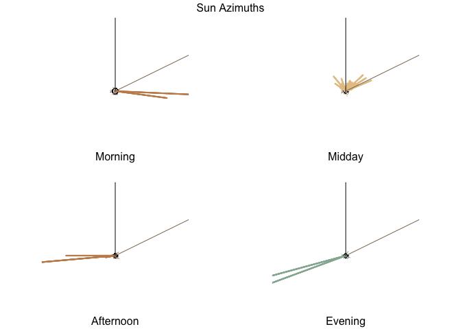

```r
par(pty = 's')
#is this ignored?

par(mfrow = c(2,2),
    cex = 0.3,
    mar = c(0,0,4.5,0))

with(subset(hd,
            GetToD(time) > morning_start &
            GetToD(time) < morning_end),
     {
PCfun(sun_az,
      col = time_cols['morning_start'],
      shrink = sqrt(length(sun_az)),
      title = "Morning")
     }
)
#add North
arrows.circular(x = circular(0,
                             template = "geographics"),
                y = 1e3)
#add feeder
arrows.circular(x = circular(-68,
                             template = "geographics"),
                y = 1e3,
                col = 'navajowhite4')

with(subset(hd,
            GetToD(time) > midday_start &
            GetToD(time) < midday_end),
     {
PCfun(sun_az,
      col =  time_cols['midday_start'],
      shrink = sqrt(length(sun_az)),
      title = "Midday")
     }
)
#add North
arrows.circular(x = circular(0,
                             template = "geographics"),
                y = 1e3)
#add feeder
arrows.circular(x = circular(-68,
                             template = "geographics"),
                y = 1e3,
                col = 'navajowhite4')

with(subset(hd,
            GetToD(time) > afternoon_start &
            GetToD(time) < afternoon_end),
     {
PCfun(sun_az,
      col = time_cols['afternoon_start'],
      shrink = sqrt(length(sun_az)),
      title = "Afternoon")
     }
)
#add North
arrows.circular(x = circular(0,
                             template = "geographics"),
                y = 1e3)
#add feeder
arrows.circular(x = circular(-68,
                             template = "geographics"),
                y = 1e3,
                col = 'navajowhite4')

with(subset(hd,
            GetToD(time) > evening_start &
            GetToD(time) < evening_end),
     {
PCfun(sun_az,
      col = time_cols['evening_start'],
      shrink = sqrt(length(sun_az)),
      title = "Evening")
     }
)
#add North
arrows.circular(x = circular(0,
                             template = "geographics"),
                y = 1e3)
#add feeder
arrows.circular(x = circular(-68,
                             template = "geographics"),
                y = 1e3,
                col = 'navajowhite4')
mtext(text = "Sun Azimuths",
      outer = TRUE,
      side = 3,
      line = -3)
```

### Add Feeder angle

To determine the expected dance directions, we need to know the azimuth angle between the sun and the feeder, for which we need the bearing from the hive to the feeder. As for the hive position, the current estimate of feeder position was determined  
from a combination of Google Maps bookmarks and photograph metadata, cross-referenced with Google Earth satellite images.

`geosphere::bearing` requires coordinates in decimal, with longitude first and then latitude, so `Dms2decimal` converts from degrees, minutes and seconds to decimal and reorders the (latitude,longitude) vector.

```r
# Hive position
# 25° 34' 18" S, 31° 10' 48" E
#-25.57167,      31.18000

# Feeder position
# 25° 34' 14" S, 31° 10' 59" E
#-25.57056,      31.18306

hive = r"(25° 34' 18" S, 31° 10' 48" E)" # N.B. this string contains literal " so needs wrapping in r"()"

feeder = r"(25° 34' 14" S, 31° 10' 59" E)"

# Define coordinates (lon, lat)
hive = Dms2decimal(hive)
feeder =  Dms2decimal(feeder)
#N.B. Dms2decimal converts from (latitude, longitude) to (longitude, latitude)
# to conform with geosphere::bearing

# Calculate bearing from hive to feeder
feeder_bearing = bearing(hive, feeder)
print(feeder_bearing, digits = 3)
```

```
## [1] 68.2
```

```r
feeder_distance = distGeo(hive, feeder)
print(feeder_distance, digits = 3)
```

```
## [1] 331
```

```r
#add feeder azimuth relative to sun position
hd = within(hd,
            {
            feeder_az = Mod360.180(feeder_bearing - sun_az)
            }
            )

print(with(hd, summary(feeder_az)), digits = 3)
```

```
##    Min. 1st Qu.  Median    Mean 3rd Qu.    Max.
##   -30.0    18.9   161.6   109.5   172.8   179.9
```

```r
print(with(hd, summary(abs(feeder_az))), digits = 3)
```

```
##    Min. 1st Qu.  Median    Mean 3rd Qu.    Max.
##   0.113  27.745 161.585 115.806 172.786 179.916
```

Based on geographic position alone, we can conclude that the feeder was at a bearing of 068° (approx. East-North-East) from the hive, ≈ 330m away. Given the hilly terrain, the ground distance flown may have been slightly further. After subtracting the sun’s azimuth, we see that the sun ranged between nearly 180° West of the feeder (presumably sunset) and precisely aligned with the feeder (presumably during the morning).

### Plot sanity checks

Plot these to get an idea of how they match up.

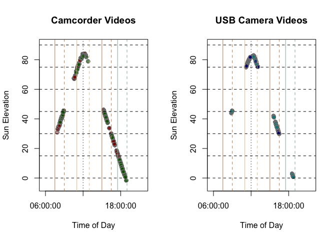

```r
cond_cols = list(
  vertical = 'darkred',
  horizontal = 'darkgreen',
  tilted = 'seagreen',
  solar = 'blue4',
  antisolar = 'cyan4',
  zenith = "skyblue3"
)

par(mfrow = c(1,2))
with(subset(hd, condition %in% c("vertical", "horizontal", "deg10")),
     {
     plot(x = GetToD(time),
          y = sun_el,
          xlim = c(20400,78060),#"06:40:00 CET" "22:41:00 CET"
          ylim = c(-1,1)*c(5,90),
          xlab = 'Time of Day',
          ylab = 'Sun Elevation',
          main = 'Camcorder Videos',
          pch = 21,
          col = 'gray50',
           bg = adjustcolor(sapply(X = condition,
                        FUN = switch,
                        vertical = cond_cols$vertical,#'darkred',
                        horizontal = cond_cols$horizontal,#'darkgreen',
                        tilted = cond_cols$tilted,#'seagreen',
                        'darkorange2'),
                        alpha.f = 0.25)
     )
     abline(h = 0:6*c(15),
            lty = 2) #limits
     abline(v =  12*60*60, #as.numeric(as.POSIXct("1970-01-01 12:00:00 UTC"))
            lty = 3)
     }
     )

#add lines indicating the approximate expected start and end of each experiment
abline(v = exper_times,
       col = time_cols,
       lty = c(1,2),
       lwd = 1
       )


with(subset(hd, condition %in% c("solar", "antisolar")),
     {
     plot(x = GetToD(time),
          y = sun_el,
          xlim = c(20400,78060),#"06:40:00 CET" "22:41:00 CET"
          ylim = c(-1,1)*c(5,90),
          xlab = 'Time of Day',
          ylab = 'Sun Elevation',
          main = 'USB Camera Videos',
          pch = 21,
          col = 'gray50',
           bg = adjustcolor(sapply(X = condition,
                        FUN = switch,
                        solar = cond_cols$solar,#'blue4',
                        antisolar = cond_cols$antisolar,#'cyan4',
                        zenith = cond_cols$zenith,#'cyan4',
                        'darkorange2'),
                        alpha.f = 0.25 )
          )
     abline(h = 0:6*c(15),
            lty = 2) #limits
     abline(v = 12*60*60, #as.numeric(as.POSIXct("1970-01-01 12:00:00 UTC"))
            lty = 3)
     }
     )


#add lines indicating the approximate expected start and end of each experiment
abline(v = exper_times,
       col = time_cols,
       lty = c(1,2),
       lwd = 1
       )
```

# Format angles

Calculate angular error mismatch between u/v components and reported video angle. Identify and report any problematic dances with errors exceeding 1°, reporting their IDs, tracked directions, and source video files. Handles edge cases by setting direction and angle values to `NA` where the tracked direction is a zero vector (no angle tracked).

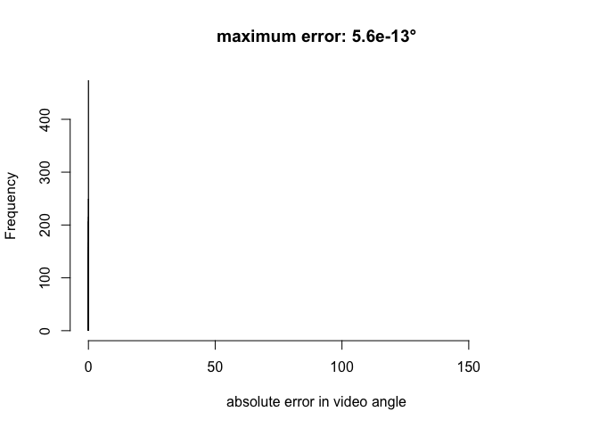

```r
#check angle format

est_err = with(hd, {
    (atan2(y = direction_v, x = direction_u) + pi/2) - rad(video_angle_deg)
  })
abs_est_err = mod_circular(abs(est_err))
#these can be out by as much as 1/(1000 000 000 000) of a degree
hist(x = abs(deg(abs_est_err)),
     breaks = 1e2,
     xlim = c(0, 180),
     # xlim = c(min(abs(deg(abs_est_err))[abs(deg(abs_est_err))>0]), 180),
     xlab = 'absolute error in video angle',
     # log = 'x',
     main = paste0('maximum error: ', signif(max(abs(deg(abs_est_err))), 3), "°" )
      )
```

```r
if(any(abs_est_err > 1))
{
  message("dances with error >1°:\n")
cbind(with(hd[abs_est_err > 1,],
     as.character(unique(ID_d))),
          unique(deg(abs_est_err[abs_est_err > 1])) )
message("tracked directions and video files:\n")
with(hd[abs_est_err > 1,],
           cbind(
     as.character(unique(ID_d)),
          unique(paste(direction_v, direction_u)),
     unique(as.character(video_file))
     )
)
#these are zero length vectors
#set them to NA
hd = within(hd,
            {
              direction_v[direction_v ==0 &
                          direction_u ==0
                          ] = NA
              direction_u[direction_v ==0 &
                          direction_u ==0
                          ] = NA
              video_angle_deg[direction_v ==0 &
                          direction_u ==0
                          ] = NA
            }
            )
}else
{print("no dances with error >1°")}
```

```
## [1] "no dances with error >1°"
```

`waggle_true_bearing` should be the direction relative to North. There is a true North for the horizontal condition, determined using a magnetic compass and correction for local magnetic declination **TODO** check about `NA` declinations.

```
## [1] "True North across videos (camera perspective)"
##    Min. 1st Qu.  Median    Mean 3rd Qu.    Max.
##     204     212     221     225     242     252
## [1] "True waggle dance bearings after correction"
##    Min. 1st Qu.  Median    Mean 3rd Qu.    Max.
##    0.16   38.84   60.65   98.06  108.04  359.85
## [1] "Reproduction error for video angle correction"
##     Min.  1st Qu.   Median     Mean  3rd Qu.     Max.
## -1.0e-12 -1.9e-13  1.4e-14  3.7e-14  2.9e-13  1.0e-12
```

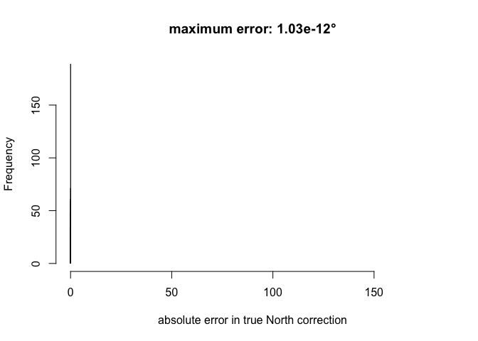

```r
with(subset(hd, condition %in% "horizontal"),
     {
       print("True North across videos (camera perspective)")
       print(
     summary(true_north_video_deg),
     digits = 2
       )
     #
     #   print(
     # summary(declination_deg)
     #   )
       print("True waggle dance bearings after correction")
       print(
         summary(waggle_true_bearing_deg),
         digits = 2
       )

       #this differs across videos
       # print(
       #   summary(waggle_true_bearing_deg - video_angle_deg),
       #   digits = 3
       # )

       #check the correction
       print("Reproduction error for video angle correction")
       print(
         summary(Mod360.180(video_angle_deg - true_north_video_deg - waggle_true_bearing_deg)),
         digits = 2
       )

       hist(x = abs(Mod360.180(video_angle_deg - true_north_video_deg - waggle_true_bearing_deg)),
     breaks = 1e2,
     xlim = c(0, 180),
     # xlim = c(min(abs(deg(abs_est_err))[abs(deg(abs_est_err))>0]), 180),
     xlab = 'absolute error in true North correction',
     # log = 'x',
     main = paste0('maximum error: ', signif(max(abs(Mod360.180(video_angle_deg - true_north_video_deg - waggle_true_bearing_deg))), 3), "°" )
      )

     }
     )
```

Dance orientation measurements vary depending on the experimental condition. Some use compass-corrected bearings whilst others rely on video alignment. To enable consistent analysis across all conditions, we need to consolidate these angles into standard formats.

```r
#assign angles to numeric

#video_angle_deg is the dance angle clockwise rel to vertical, except  error
hd = within(hd,
            {
              # bearing = deg(atan2(y = direction_v, x = direction_u) + pi/2) %% 360
              bearing = mapply(FUN = switch,
                               EXPR = condition,
                               vertical =  video_angle_deg + sun_az, #aligned by default
                               horizontal = waggle_true_bearing_deg, #corrected with compass
                               deg10 = waggle_true_bearing_deg,
                               antisolar = waggle_true_bearing_deg, #now calibrated
                               solar = waggle_true_bearing_deg, #now calibrated
                               zenith = waggle_true_bearing_deg, #now calibrated
                               video_angle_deg + sun_az
                              )
              dance_sun_angle = Mod360.180(bearing - sun_az)# angle between dance and sun
              signed_angle = Mod360.180(bearing)  # bearing between -180 and 180
              angle = rad(signed_angle)# circular format is not needed for organising

              rm('video_angle_deg')
            }
            )

sm_angles = with(hd, sapply(list(bearing, signed_angle, angle), FUN = summary))
colnames(sm_angles) = c("bearing", "signed_angle", "angle")
print("Final angular values")
```

```
## [1] "Final angular values"
```

```r
print(
sm_angles,
digits = 2
)
```

```
##         bearing signed_angle angle
## Min.       0.16         -180 -3.14
## 1st Qu.   73.23           15  0.26
## Median   273.99           62  1.09
## Mean     264.57           43  0.75
## 3rd Qu.  436.23           92  1.60
## Max.     690.84          180  3.14
```

# Inspect dances

### Plot an example dance

For example we can look at the first dances for recorded on each day for each one of the conditions. Here we plot the estimated dance relative to the sun (at 0°). Feeder azimuth relative to the sun is shown as an brown line.

```
## [1] 20250119
## [1] "First dance for each condition after subsetting"
##            [,1]
## vertical   "16b_00033_17:20:00_20250119"
## horizontal "22b_00054_18:00:00_20250119"
## antisolar  NA
## solar      NA
## zenith     NA
## tilted     NA
```

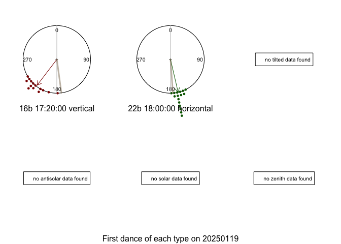

```
## [1] 20250120
## [1] "First dance for each condition after subsetting"
##            [,1]
## vertical   "22b_00011_08:21:00_20250120"
## horizontal "16b_00050_16:32:00_20250120"
## antisolar  NA
## solar      NA
## zenith     NA
## tilted     NA
```

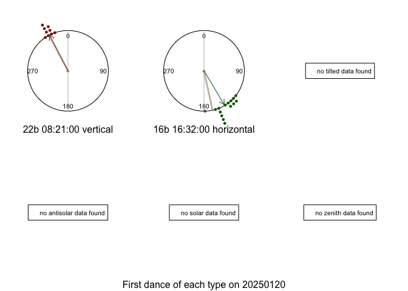

```
## [1] 20250121
## [1] "First dance for each condition after subsetting"
##            [,1]
## vertical   "22b_00002_10:32:00_20250121"
## horizontal "22b_00025_11:55:00_20250121"
## antisolar  "87r_antisolar-.2025-01-21 11-22-26_12:24:00_20250121"
## solar      "22b_solar_2025-01-21 12-03-51_13:05:00_20250121"
## zenith     NA
## tilted     NA
```

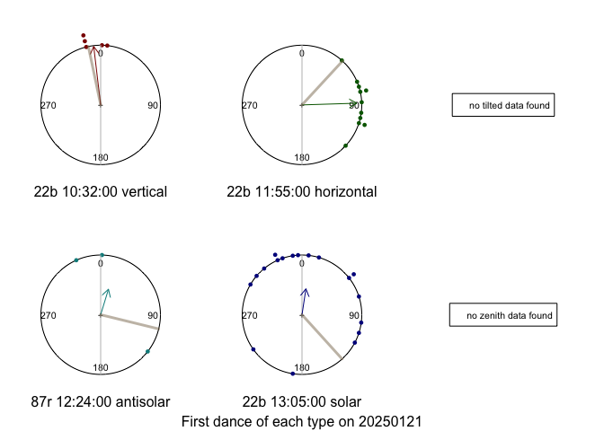

```
## [1] 20250122
## [1] "First dance for each condition after subsetting"
##            [,1]
## vertical   "11r_00028_15:22:00_20250122"
## horizontal "22b_00038_15:45:00_20250122"
## antisolar  "73b_2025-01-22 15-00-37_16:02:00_20250122"
## solar      "22b_2025-01-22 15-21-33_16:20:00_20250122"
## zenith     "90r_2025-01-22 17-34-18_18:34:00_20250122"
## tilted     NA
```

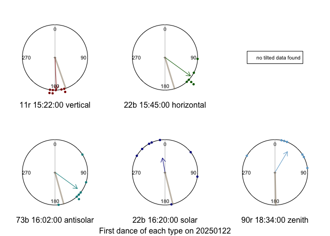

```
## [1] 20250123
## [1] "First dance for each condition after subsetting"
##            [,1]
## vertical   "11r_00048_15:36:00_20250123"
## horizontal "20y_00058_18:00:00_20250123"
## antisolar  "80w_2025-01-23 11-39-25_12:38:00_20250123"
## solar      NA
## zenith     NA
## tilted     NA
```

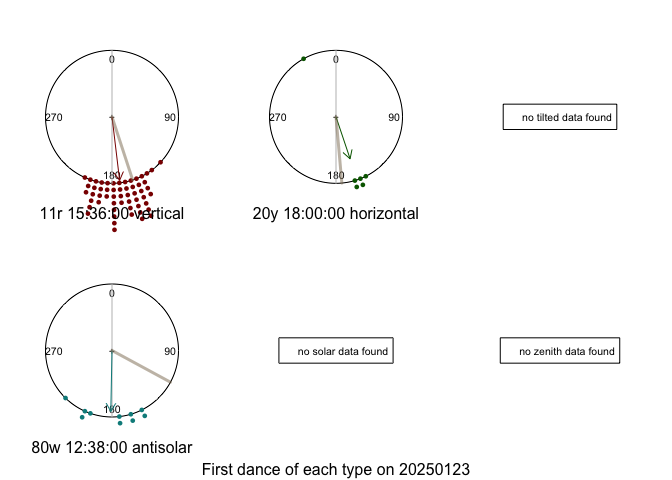

```
## [1] 20250124
## [1] "First dance for each condition after subsetting"
##            [,1]
## vertical   "17y_00020_17:45:00_20250124"
## horizontal "23y_00030_18:37:00_20250124"
## antisolar  NA
## solar      NA
## zenith     NA
## tilted     NA
```

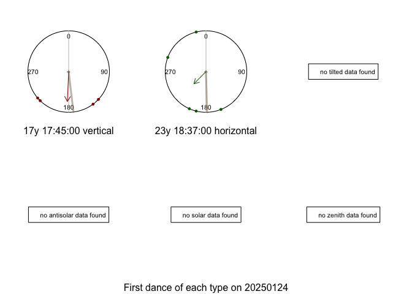

```
## [1] 20250125
## [1] "First dance for each condition after subsetting"
##            [,1]
## vertical   "11r_00041_12:00:00_20250125"
## horizontal "22b_00042_12:05:00_20250125"
## antisolar  NA
## solar      NA
## zenith     NA
## tilted     NA
```

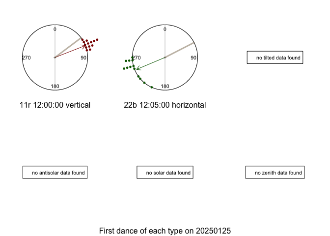

```
## [1] 20250126
## [1] "First dance for each condition after subsetting"
##            [,1]
## vertical   "11r_00005_11:09:00_20250126"
## horizontal "17y_00043_18:27:00_20250126"
## antisolar  "66b_2025-01-26 11-28-07_12:28:00_20250126"
## solar      "73b_2025-01-26 11-32-56_12:32:00_20250126"
## zenith     NA
## tilted     NA
```

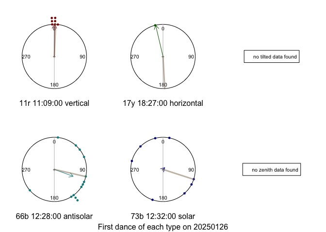

```
## [1] 20250127
## [1] "First dance for each condition after subsetting"
##            [,1]
## vertical   "20y_00007_08:56:00_20250127"
## horizontal "20y_00017_11:44:00_20250127"
## antisolar  "22b_2025-01-27 11-41-59_12:43:00_20250127"
## solar      "66b_2025-01-27 12-03-34_13:04:00_20250127"
## zenith     "90r_2025-01-27 17-22-33_18:23:00_20250127"
## tilted     "20y_00035_15:28:00_20250127"
```

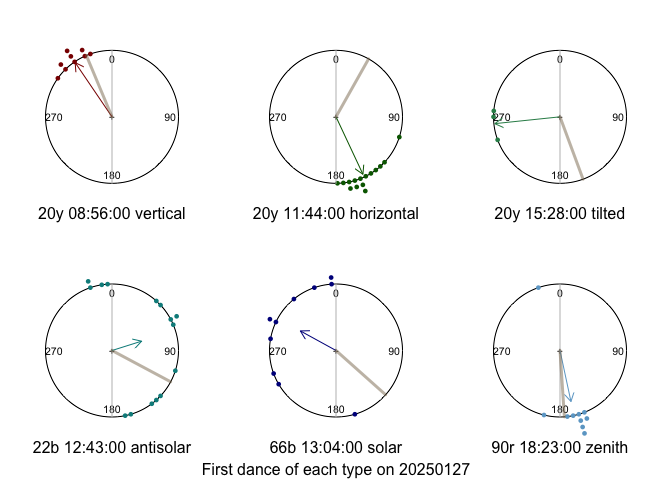

```
## [1] 20250128
## [1] "First dance for each condition after subsetting"
##            [,1]
## vertical   "20y_00001_07:53:00_20250128"
## horizontal "17y_00034_11:05:00_20250128"
## antisolar  "20y_2025-01-28 07-50-03_08:51:00_20250128"
## solar      "20y_2025-01-28 10-38-24_11:37:00_20250128"
## zenith     NA
## tilted     "17y_00065_18:07:00_20250128"
```

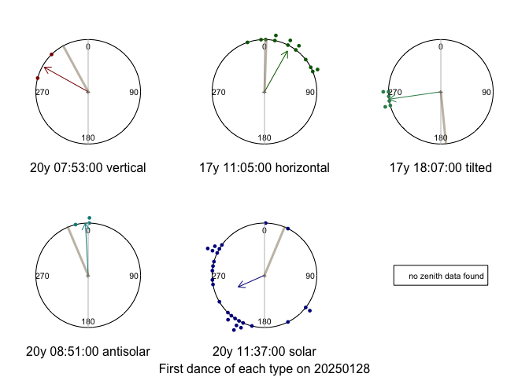

```r
for(example_day in unique(hd$day))
{
  print(example_day)
  #select first dance for each condition from example day
day_lst = FirstDanceCond(dta = hd,
                        subset = day %in% example_day)
#plot 1st dance for each condition
Plt_subs(subs = day_lst$example_subs,
         angle_for = "sun",#plot with sun azimuth as frame of reference
         cond_cols = cond_cols,
         title =  paste("First dance of each type on", example_day)
         )
}
```

# Calculate dance offset from feeder

To compare the dance angles against the true feeder direction, we calculate the angular offset between each dance and the expected feeder bearing, measured relative to sun position or the vertical .

1. Calculate the angle between the dance bearing and the feeder bearing.
2. Convert to absolute angle in degrees for easier interpretation.
3. Print summary statistics of dance accuracy (absolute offset) for each experimental condition

```r
#assign angles to numeric

hd = within(hd,
            {
              feeder_angle = mod_circular(rad(dance_sun_angle - feeder_az))# angle between dance and expected dance
              abs_feeder_angle_deg = deg(abs(as.numeric(feeder_angle)))# absolute angle in numeric format
            }
            )
print("Absolute dance offset from true feeder bearing.")
```

```
## [1] "Absolute dance offset from true feeder bearing."
```

```r
for(stim in unique(hd$condition))
{
  print(stim)
print(
  with(subset(hd, condition %in% stim), summary(abs_feeder_angle_deg)),
  digits = 2
)
}
```

```
## [1] "vertical"
##    Min. 1st Qu.  Median    Mean 3rd Qu.    Max.
##   0.016   9.310  20.372  25.766  39.182 158.543
## [1] "horizontal"
##    Min. 1st Qu.  Median    Mean 3rd Qu.    Max.
##   0.077  12.025  31.558  51.305  64.377 179.574
## [1] "antisolar"
##    Min. 1st Qu.  Median    Mean 3rd Qu.    Max.
##   0.034  17.454  55.362  65.528 103.960 178.983
## [1] "solar"
##    Min. 1st Qu.  Median    Mean 3rd Qu.    Max.
##    0.44   95.25  140.37  123.49  164.31  179.97
## [1] "zenith"
##    Min. 1st Qu.  Median    Mean 3rd Qu.    Max.
##     2.9    19.6    34.5    75.2   143.8   169.7
## [1] "tilted"
##    Min. 1st Qu.  Median    Mean 3rd Qu.    Max.
##    0.31   52.49   75.48   72.92   93.40  179.29
```

On average, vertical dances are ≈20°–25° from the expected direction. Horizontal dances are less accurate, ≈30°–50° from the expected direction. For the other conditions divergences are much larger. For solar skylight in particular, there appear to be more dances opposite the feeder than towards it (half of dances >140° from feeder).

### Plot example feeder angles

Plot individual examples from each condition relative to the correct feeder direction.

1. Loop through each experimental day
2. Identify the first dance for each condition
3. Plot the angular offset to the expected feeder bearing, showing sun azimuth in yellow for reference.

```
## [1] 20250119
## [1] "First dance for each condition after subsetting"
##            [,1]
## vertical   "16b_00033_17:20:00_20250119"
## horizontal "22b_00054_18:00:00_20250119"
## antisolar  NA
## solar      NA
## zenith     NA
## tilted     NA
```

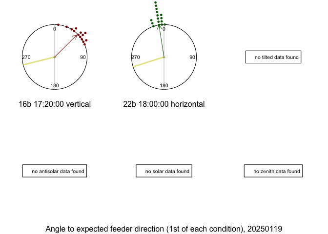

```
## [1] 20250120
## [1] "First dance for each condition after subsetting"
##            [,1]
## vertical   "22b_00011_08:21:00_20250120"
## horizontal "16b_00050_16:32:00_20250120"
## antisolar  NA
## solar      NA
## zenith     NA
## tilted     NA
```

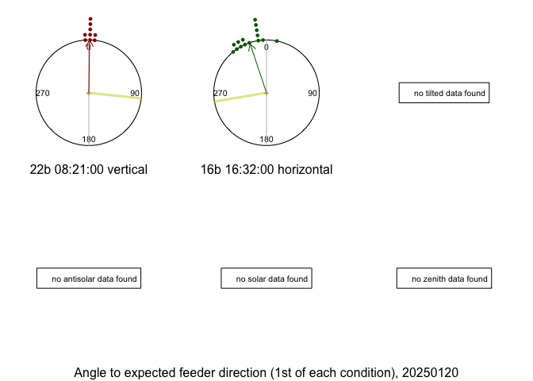

```
## [1] 20250121
## [1] "First dance for each condition after subsetting"
##            [,1]
## vertical   "22b_00002_10:32:00_20250121"
## horizontal "22b_00025_11:55:00_20250121"
## antisolar  "87r_antisolar-.2025-01-21 11-22-26_12:24:00_20250121"
## solar      "22b_solar_2025-01-21 12-03-51_13:05:00_20250121"
## zenith     NA
## tilted     NA
```

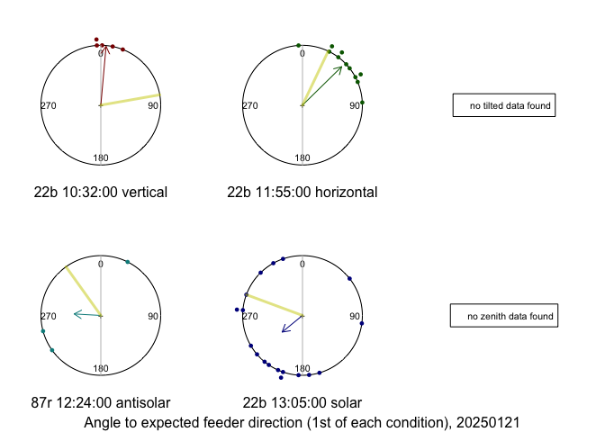

```
## [1] 20250122
## [1] "First dance for each condition after subsetting"
##            [,1]
## vertical   "11r_00028_15:22:00_20250122"
## horizontal "22b_00038_15:45:00_20250122"
## antisolar  "73b_2025-01-22 15-00-37_16:02:00_20250122"
## solar      "22b_2025-01-22 15-21-33_16:20:00_20250122"
## zenith     "90r_2025-01-22 17-34-18_18:34:00_20250122"
## tilted     NA
```

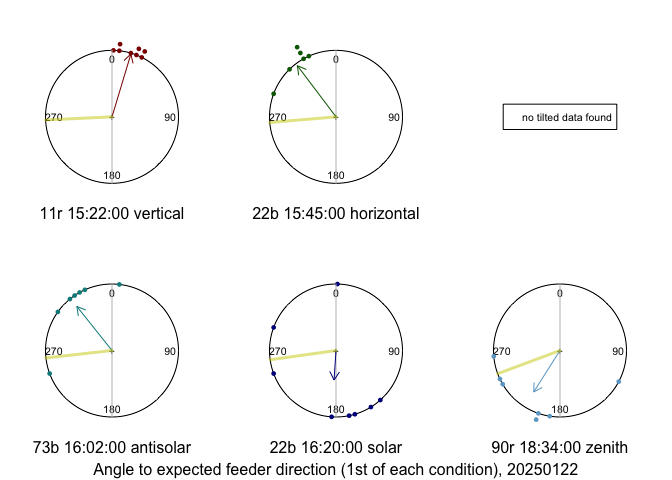

```
## [1] 20250123
## [1] "First dance for each condition after subsetting"
##            [,1]
## vertical   "11r_00048_15:36:00_20250123"
## horizontal "20y_00058_18:00:00_20250123"
## antisolar  "80w_2025-01-23 11-39-25_12:38:00_20250123"
## solar      NA
## zenith     NA
## tilted     NA
```

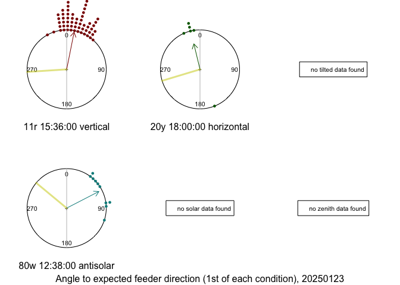

```
## [1] 20250124
## [1] "First dance for each condition after subsetting"
##            [,1]
## vertical   "17y_00020_17:45:00_20250124"
## horizontal "23y_00030_18:37:00_20250124"
## antisolar  NA
## solar      NA
## zenith     NA
## tilted     NA
```

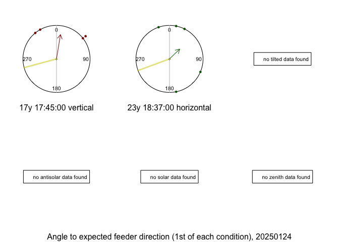

```
## [1] 20250125
## [1] "First dance for each condition after subsetting"
##            [,1]
## vertical   "11r_00041_12:00:00_20250125"
## horizontal "22b_00042_12:05:00_20250125"
## antisolar  NA
## solar      NA
## zenith     NA
## tilted     NA
```

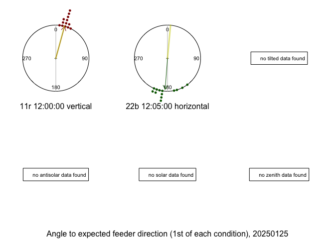

```
## [1] 20250126
## [1] "First dance for each condition after subsetting"
##            [,1]
## vertical   "11r_00005_11:09:00_20250126"
## horizontal "17y_00043_18:27:00_20250126"
## antisolar  "66b_2025-01-26 11-28-07_12:28:00_20250126"
## solar      "73b_2025-01-26 11-32-56_12:32:00_20250126"
## zenith     NA
## tilted     NA
```

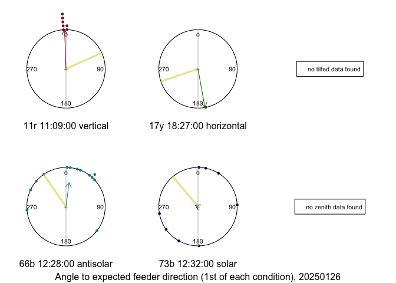

```
## [1] 20250127
## [1] "First dance for each condition after subsetting"
##            [,1]
## vertical   "20y_00007_08:56:00_20250127"
## horizontal "20y_00017_11:44:00_20250127"
## antisolar  "22b_2025-01-27 11-41-59_12:43:00_20250127"
## solar      "66b_2025-01-27 12-03-34_13:04:00_20250127"
## zenith     "90r_2025-01-27 17-22-33_18:23:00_20250127"
## tilted     "20y_00035_15:28:00_20250127"
```

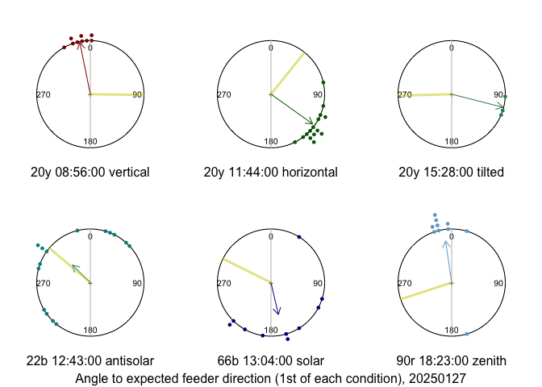

```
## [1] 20250128
## [1] "First dance for each condition after subsetting"
##            [,1]
## vertical   "20y_00001_07:53:00_20250128"
## horizontal "17y_00034_11:05:00_20250128"
## antisolar  "20y_2025-01-28 07-50-03_08:51:00_20250128"
## solar      "20y_2025-01-28 10-38-24_11:37:00_20250128"
## zenith     NA
## tilted     "17y_00065_18:07:00_20250128"
```

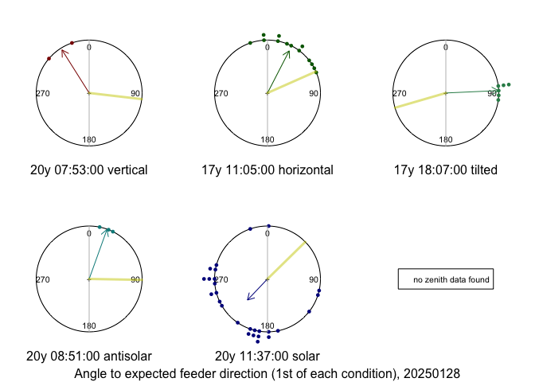

```r
for (example_day in unique(hd$day)) {
  print(example_day)
  #select first dance for each condition from example day
  day_lst = FirstDanceCond(
    dta = hd,
    subset = day %in% example_day
  )
  #plot 1st dance for each condition
  Plt_subs(
    subs = day_lst$example_subs,
    angle_for = "feeder",#plot with feeder azimuth as frame of reference
    cond_cols = cond_cols,
    title = paste(
      "Angle to expected feeder direction (1st of each condition),",
      example_day
    )
  )
}
```

As before, we notice that not all dances align well with the expected direction. This likely results from a combination of sun azimuth and elevation, as well as the part of the sky that is visible.

# Write out reorganised data

In the final data frame, we can remove some of the variables used only to check data quality, since those checks have now been performed (or can be added) above.

```r
# names(hd)

rm_lst =  c(
  # "waggle_run",
  # "condition",
  # "csv_file",
  "direction_u",
  "direction_v",
  "true_north_video_deg",
  "waggle_true_bearing_deg",
  "mean_magnetic_north_deg",
  "true_north_calibration_deg",
  # "calibration_quality_flag",
  "start_x",
  "start_y",
  # "calibration_R",
  "declination_deg",
  # "video_file",
  # "day",
  # "time",
  # "ID_d",
  # "ID",
  "date_fail",
  "utc_time",
  # "sast_time",
  "expected_time",
  # "sun_az",
  # "sun_el",
  # "feeder_az",
  # "angle",
  # "signed_angle",
  # "bearing",
  # "dance_sun_angle",
  "abs_feeder_angle_deg"
  # "feeder_angle"
)

hd = within(hd,
            {
               rm(list = rm_lst)
            }
            )

print("Variables removed:")
```

```
## [1] "Variables removed:"
```

```r
print(rm_lst)
```

```
##  [1] "direction_u"                "direction_v"
##  [3] "true_north_video_deg"       "waggle_true_bearing_deg"
##  [5] "mean_magnetic_north_deg"    "true_north_calibration_deg"
##  [7] "start_x"                    "start_y"
##  [9] "declination_deg"            "date_fail"
## [11] "utc_time"                   "expected_time"
## [13] "abs_feeder_angle_deg"
```

```r
print("                                                                                                Variables kept:")
```

```
## [1] "                                                                                                Variables kept:"
```

```r
print(names(hd))
```

```
##  [1] "waggle_run"               "condition"
##  [3] "csv_file"                 "calibration_quality_flag"
##  [5] "calibration_R"            "video_file"
##  [7] "day"                      "time"
##  [9] "ID_d"                     "ID"
## [11] "sast_time"                "sun_az"
## [13] "sun_el"                   "feeder_az"
## [15] "angle"                    "signed_angle"
## [17] "dance_sun_angle"          "bearing"
## [19] "feeder_angle"
```

Now that the data has been successfully reorganised, write out just the simplified data frame to CSV, in the same location as the original files.

```r
# Write out table

write.table(x = hd,
            file = file.path(unique(dirname(path_file))[1], "hs_dance_reorg.csv"),
            sep = ',',
            row.names = FALSE
            )
```